# Navigation

You are welcome to use this coding environment to train your agent for the project. Follow the instructions below to get started!

### 1. Start the Environment

Run the next code cell to install a few packages. This line will take a few minutes to run!

```python
!pip -q install ./python
```

```
tensorflow 1.7.1 has requirement numpy>=1.13.3, but you'll have numpy 1.12.1 which is incompatible.
ipython 6.5.0 has requirement prompt-toolkit<2.0.0,>=1.0.15, but you'll have prompt-toolkit 3.0.10 which is incompatible.
```

The environment is already saved in the Workspace and can be accessed at the file path provided below. Please run the next code cell without making any changes.

```python
from unityagents import UnityEnvironment
import numpy as np

# please do not modify the line below
env = UnityEnvironment(file_name="/data/Banana_Linux_NoVis/Banana.x86_64")
```

```
INFO:unityagents:
'Academy' started successfully!
Unity Academy name: Academy
        Number of Brains: 1
        Number of External Brains : 1
        Lesson number : 0
        Reset Parameters :

Unity brain name: BananaBrain
        Number of Visual Observations (per agent): 0
        Vector Observation space type: continuous
        Vector Observation space size (per agent): 37
        Number of stacked Vector Observation: 1
        Vector Action space type: discrete
        Vector Action space size (per agent): 4
        Vector Action descriptions: , , ,
```

Environments contain *brains* which are responsible for deciding the actions of their associated agents. Here we check for the first brain available, and set it as the default brain we will be controlling from Python.

```python
# get the default brain
brain_name = env.brain_names[0]
brain = env.brains[brain_name]
```

### 2. Examine the State and Action Spaces

Run the code cell below to print some information about the environment.

```python
# reset the environment
env_info = env.reset(train_mode=True)[brain_name]

# number of agents in the environment
print('Number of agents:', len(env_info.agents))

# number of actions
action_size = brain.vector_action_space_size
print('Number of actions:', action_size)

# examine the state space
state = env_info.vector_observations[0]
print('States look like:', state)
state_size = len(state)
print('States have length:', state_size)
```

```
Number of agents: 1
Number of actions: 4
States look like: [ 1.          0.          0.          0.          0.84408134  0.          0.
  1.          0.          0.0748472   0.          1.          0.          0.
  0.25755     1.          0.          0.          0.          0.74177343
  0.          1.          0.          0.          0.25854847  0.          0.
  1.          0.          0.09355672  0.          1.          0.          0.
  0.31969345  0.          0.        ]
States have length: 37
```

### 3. Take Random Actions in the Environment

In the next code cell, you will learn how to use the Python API to control the agent and receive feedback from the environment.

Note that **in this coding environment, you will not be able to watch the agent while it is training**, and you should set `train_mode=True` to restart the environment.

```python
env_info = env.reset(train_mode=True)[brain_name]  # reset the environment
state = env_info.vector_observations[0]            # get the current state
score = 0                                          # initialize the score
while True:
    action = np.random.randint(action_size)        # select an action
    env_info = env.step(action)[brain_name]        # send the action to the environment
    next_state = env_info.vector_observations[0]   # get the next state
    reward = env_info.rewards[0]                   # get the reward
    done = env_info.local_done[0]                  # see if episode has finished
    score += reward                                # update the score
    state = next_state                             # roll over the state to next time step
    if done:                                       # exit loop if episode finished
        break

print("Score: {}".format(score))
```

```
Score: 0.0
```

When finished, you can close the environment.

```python
env.close()
```

### 4. It's Your Turn!

Now it's your turn to train your own agent to solve the environment! A few **important notes**:

- When training the environment, set `train_mode=True`, so that the line for resetting the environment looks like the following:

  ```
  env_info = env.reset(train_mode=True)[brain_name]
  ```

- To structure your work, you're welcome to work directly in this Jupyter notebook, or you might like to start over with a new file! You can see the list of files in the workspace by clicking on *Jupyter* in the top left corner of the notebook.
- In this coding environment, you will not be able to watch the agent while it is training. However, *after training the agent*, you can download the saved model weights to watch the agent on your own machine!

```python
!pip -q install ./python
```

```
tensorflow 1.7.1 has requirement numpy>=1.13.3, but you'll have numpy 1.12.1 which is incompatible.
ipython 6.5.0 has requirement prompt-toolkit<2.0.0,>=1.0.15, but you'll have prompt-toolkit 3.0.10 which is incompatible.
```

### Create Banana Collector Unity Environment

```python
from unityagents import UnityEnvironment
import numpy as np

# please do not modify the line below
env = UnityEnvironment(file_name="/data/Banana_Linux_NoVis/Banana.x86_64")

# get the default brain
brain_name = env.brain_names[0]
brain = env.brains[brain_name]

# reset the environment
env_info = env.reset(train_mode=True)[brain_name]

# number of agents in the environment
print('Number of agents:', len(env_info.agents))

# number of actions
action_size = brain.vector_action_space_size
print('Number of actions:', action_size)

# examine the state space
state = env_info.vector_observations[0]
print('States look like:', state)
state_size = len(state)
print('States have length:', state_size)
```

```
INFO:unityagents:
'Academy' started successfully!
Unity Academy name: Academy
        Number of Brains: 1
        Number of External Brains : 1
        Lesson number : 0
        Reset Parameters :

Unity brain name: BananaBrain
        Number of Visual Observations (per agent): 0
        Vector Observation space type: continuous
        Vector Observation space size (per agent): 37
        Number of stacked Vector Observation: 1
        Vector Action space type: discrete
        Vector Action space size (per agent): 4
        Vector Action descriptions: , , ,
```

```
Number of agents: 1
Number of actions: 4
States look like: [ 1.          0.          0.          0.          0.84408134  0.          0.
  1.          0.          0.0748472   0.          1.          0.          0.
  0.25755     1.          0.          0.          0.          0.74177343
  0.          1.          0.          0.          0.25854847  0.          0.
  1.          0.          0.09355672  0.          1.          0.          0.
  0.31969345  0.          0.        ]
States have length: 37
```

### Parameters

```python
#Environment parameters
#state_size = 37
#action_size = 4

#Model hidden layer nodes
FC1 = 512
FC2 = 1024
FC3 = 128

#Replay Buffer
BUFFER_SIZE = 100000     # Replay buffer size, 300 steps per episode
BATCH_SIZE = 32         # Batch size

#Learning Parameters
GAMMA = 0.995           # Discount gamma factor
TAU = .001              # Soft update of target parameters
LR = 0.0001              # learning rate
REPLAY_INTERVAL = 4     # How often replay implemented
EPS_START = .998         # Starting  epsilon, for epsilon-greedy action selection
EPS_END = 0.03          # Minimum value of epsilon
EPS_DECAY = 0.997       # Factor per episode decreasing epsilon
EPISODES_MAX = 900      # Maximum number of training episodes, stop earlier if score >13, 100 runs

#Other
SEED = 64               # Allow for repeatability
EPISODE_PRINT = 10      # Contol interval of printing score during training
SCORE_WINDOW_SIZE = 100 # Window size to calculate consecutive episode window averages
SCORE_THRESHOLD = 13.0  # Score threshold selected for trained agent for this game

#Run on GPU or CPU
import torch
if torch.cuda.is_available():
    device = torch.device('cuda')
else:
    device = torch.device('cpu')
```

### 5. Define Deep Q Model Class

Define Model Network. Type: Fully Connected Linear Network Input: Staes = 37 Hidden Layers: = 3 ; Defined by FC1, FC2, FC3 Output: Actions =4

```python
import torch.nn as nn
import torch.nn.functional as F
from torch.autograd import Variable

#Linear Network, 3 Hidden Layers, input:state_size , output: action_size
class DQN_Model(nn.Module):
    def __init__(self):
        super(DQN_Model, self).__init__()
        self.seed = torch.manual_seed(SEED)
        self.fc1 = nn.Linear(state_size, FC1)
        self.fc2 = nn.Linear(FC1, FC2)
        self.fc3 = nn.Linear(FC2, FC3)
        self.fc4 = nn.Linear(FC3, action_size)

    def forward(self, state):
        x = F.relu(self.fc1(state))
        x = F.relu(self.fc2(x))
        x = F.relu(self.fc3(x))
        x = self.fc4(x)
        return x
```

### Define Agent Class

```
init: states, actions, local/target models, optimizer
step: store experiences to replay each step
act: epsilon greedy action
learn: mse loss between target/expected, soft update

Implementing approach with:
    Experience Replay - Avoid high correlation of sequential training
    Fixed Q-Target - Address correlation between the target and the parameters for a single model af a/s
    Get Q value for current state and action and target  q value for next state and action
    Double DQN - Two estimators attempt agree on actions - REMOVED, did not converge as fast
```

```python
import numpy as np
import torch.optim as optim
import random

class DQN_Agent():
    #Adapted from Deep_Q_Network_Solution.ipynb as part of Udacity Lesson
    #Re-used soft update method, use of .gather, and step replay funcion
    #Class init
    def __init__(self):
        self.seed = random.seed(SEED)
        # DQ-Networks (local and target). Instantiate DQN_Model
        # Run on GPU (.to(device) if available else CPU; move before optimizers)
        self.dqn_current  = DQN_Model().to(device)
        self.dqn_target = DQN_Model().to(device)
        #torch.optim.SGD was not effective -- flat
        #Optimizer Adam: Stochastic Optimization, performed well
        #torch.optim.Adam(params, lr=0.001, betas=(0.9, 0.999), eps=1e-08, weight_decay=0, amsgrad=False)
        self.optimizer = optim.Adam(self.dqn_current.parameters(), lr=LR)
        # Instantiate Replay memory
        self.memory = ReplayBuffer()

        # Initialize time step (for REPLAY_INTERVAL)
        self.time_step = 0


    #Select and return action
    def get_action(self, state, eps):
        #Get action from current
        state = torch.from_numpy(state).float().unsqueeze(0).to(device)
        self.dqn_current.eval()
        with torch.no_grad():
            action_values = self.dqn_current(state).to(device)
        self.dqn_current.train()

        # Epsilon-greedy action selection
        if random.random() > eps:
            return np.argmax(action_values.data.cpu().numpy())
        else:
            return np.random.randint(action_size)

    def dqn_learn(self, experiences):
        #experiences (Tuple[torch.Tensor]): tuple of (s, a, r, s', done) tuples
        states, actions, rewards, next_states, dones = experiences
        self.dqn_target.eval()
        q_target_next = self.dqn_target(next_states).detach().max(1)[0].unsqueeze(1)

        # Compute Q targets/expected for current states
        self.dqn_current.eval()
        q_target = rewards + (GAMMA * q_target_next * (1 - dones))
        q_current = self.dqn_current(states).gather(1, actions)

        # Minimize the loss
        self.dqn_current.train()
        self.dqn_target.train()
        criterion = torch.nn.MSELoss().to(device)
        loss = criterion(q_current, q_target).to(device)
        self.optimizer.zero_grad()
        loss.backward()
        self.optimizer.step()

        # Soft Update target network, for discrete
        #target_weights = target_weights * (1-TAU) + q_weights * TAU where TAU 0-1
        #Method based on
        for target_param, current_param in zip(self.dqn_target.parameters(), self.dqn_current.parameters()):
            target_param.data.copy_(TAU * current_param.data + (1.0 - TAU) * target_param.data)

    #Record data for step in replay memory
    def record_step(self, state, action, reward, next_state, done):
        # Save experience in replay memory
        self.memory.add(state, action, reward, next_state, done)
       # Learn after number of time steps
        self.time_step = self.time_step + 1
        if self.time_step % REPLAY_INTERVAL == 0:
            # If enough samples are available in memory, get random subset and learn
            if len(self.memory) > BATCH_SIZE:
                experiences = self.memory.sample()
                self.dqn_learn(experiences)
```

### Define ReplayBuffer Class

```
init: buffer/batch size; state/action size
add: add experience to memory
sample: get exereiences = batch_size
len: current memory used
```

```python
from collections import namedtuple, deque

class ReplayBuffer:
    def __init__(self):
        # https://acsweb.ucsd.edu/~wfedus/pdf/replay.pdf indicated larger buffer, better performance 20:1 for buffer size
        # and 4 for replay interval is typical for dqn, ALso benefit to dropping older experiences so
        # using deque allows older experience to drop off
        # Each episone ~300 steps, and should converge ~500 so taking 15:1 = 10000 buffer size
        self.memory = deque(maxlen=BUFFER_SIZE)
        self.batch_size = BATCH_SIZE
        self.experience = namedtuple("buffer", field_names=["state", "action", "reward", "next_state", "done"])
        self.seed = random.seed(SEED)

    #Add Experience
    def add(self, state, action, reward, next_state, done):
        self.memory.append(self.experience(state, action, reward, next_state, done*1))

    #Sample a batch of experiences
    def sample(self):
        #Creates random sample as list
        experiences = random.sample(self.memory, BATCH_SIZE)
        states, actions, rewards, next_states, dones = [],[],[],[],[]
        for e in experiences:
            #states, actions, rewards, next_states, dones = e = e[0],e[1],e[2],e[3],e[4]
            states.append(e[0]), actions.append(e[1]), rewards.append(e[2]), next_states.append(e[3]), dones.append(e[4]*1)
        return (torch.FloatTensor(states).view(BATCH_SIZE,-1).to(device),
            torch.LongTensor(actions).view(BATCH_SIZE,-1).to(device),
            torch.FloatTensor(rewards).view(BATCH_SIZE,-1).to(device),
            torch.FloatTensor(next_states).view(BATCH_SIZE,-1).to(device),
            torch.FloatTensor(dones).view(BATCH_SIZE,-1).to(device) )

    #Clear Buffer
    def clear(self):
        self.memory.queue.clear()

    #Current Memory Used
    def __len__(self):
        return len(self.memory)
```

### Define Agent Training Routine

```python
import math
def DQN_Train(episodes=EPISODES_MAX):
    #Variables declarations
    agent= DQN_Agent()
    scores = []                        # scores from each episode
    scores_window = deque(maxlen=SCORE_WINDOW_SIZE)  # Last 100 scores, deque circular buffer; need 13 ave 100 consecutive runs
    eps = EPS_START                    # epsilon Start

    #Epsisode loop for training
    for episode in range(1, episodes+1):
        env_info = env.reset(train_mode=True)[brain_name]  # reset the environment
        state = env_info.vector_observations[0]            # get the current state
        score = 0
        step_t = 0
        while True:
            action = agent.get_action(state, eps)          # select an action
            env_info = env.step(action)[brain_name]        # send the action to the environment
            next_state = env_info.vector_observations[0]   # get the next state
            reward = env_info.rewards[0]                   # get the reward
            done = env_info.local_done[0]                  # see if episode has finished
            agent.record_step(state, action, reward, next_state, done) #
            score += reward                                # update the score
            state = next_state                             # roll over the state to next time step
            if done:                                       # exit loop if episode finished
                break
        scores_window.append(score)                        # save most recent score
        scores.append(score)

       #Decrease epsilon as learning progresses
        #eps gready exponential_decay from http://takashinagata.com/2020/04/09/Quick_Recap_of_eps_greedy.html
        #eps = max(EPS_END, EPS_END + (EPS_START - EPS_END) * math.exp(-1. * episode / EPS_DECAY))
        #eps compounding_dacay
            #version 1 eps = max(EPS_END, EPS_END + (EPS_START - EPS_END) * EPS_DECAY**(episode))
            #version 2 eps = max(EPS_END, EPS_DECAY**(episode))
            #version 3 eps = eps = max(EPS_END, EPS_DECAY**( max( (episode-100),EPS_START) ))
        eps = max(EPS_END, EPS_DECAY**(episode))

        #Score Avg, Standard Deviation
        avg_score = np.mean(scores_window)
        score_std = np.std(scores_window)

        #Print prgress
        if episode % EPISODE_PRINT == 0:
            print('Episode: {}\tAvg: {:.1f}\t EPS: {:.2f}\t Std: {:.2f}'.format(episode, avg_score, eps, score_std ))
        #Save wieghts every 100
        if episode % 100 == 0:
            torch.save(agent.dqn_current.state_dict(), 'model.pt')

    return scores
```

## Run Training

```python
EPISODE_PRINT = 10
SEED = 64
EPS_DECAY = 0.98
EPS_END = 0.03
LR = 0.0001
BATCH_SIZE = 64
scores = DQN_Train(episodes=500)
```

```
Episode: 10	Avg: 0.3	 EPS: 0.82	 Std: 1.10
Episode: 20	Avg: -0.1	 EPS: 0.67	 Std: 1.53
Episode: 30	Avg: 0.2	 EPS: 0.55	 Std: 1.76
Episode: 40	Avg: 0.5	 EPS: 0.45	 Std: 1.72
Episode: 50	Avg: 0.9	 EPS: 0.36	 Std: 1.92
Episode: 60	Avg: 1.4	 EPS: 0.30	 Std: 2.39
Episode: 70	Avg: 1.7	 EPS: 0.24	 Std: 2.57
Episode: 80	Avg: 2.1	 EPS: 0.20	 Std: 2.74
Episode: 90	Avg: 2.4	 EPS: 0.16	 Std: 2.90
Episode: 100	Avg: 2.4	 EPS: 0.13	 Std: 2.79
Episode: 110	Avg: 3.0	 EPS: 0.11	 Std: 3.34
Episode: 120	Avg: 3.5	 EPS: 0.09	 Std: 3.29
Episode: 130	Avg: 3.8	 EPS: 0.07	 Std: 3.19
Episode: 140	Avg: 4.4	 EPS: 0.06	 Std: 3.40
Episode: 150	Avg: 4.6	 EPS: 0.05	 Std: 3.48
Episode: 160	Avg: 4.7	 EPS: 0.04	 Std: 3.60
Episode: 170	Avg: 4.9	 EPS: 0.03	 Std: 3.80
Episode: 180	Avg: 4.9	 EPS: 0.03	 Std: 3.80
Episode: 190	Avg: 5.2	 EPS: 0.03	 Std: 4.21
Episode: 200	Avg: 6.1	 EPS: 0.03	 Std: 4.63
Episode: 210	Avg: 6.2	 EPS: 0.03	 Std: 4.52
Episode: 220	Avg: 6.9	 EPS: 0.03	 Std: 4.79
Episode: 230	Avg: 7.6	 EPS: 0.03	 Std: 4.95
Episode: 240	Avg: 8.2	 EPS: 0.03	 Std: 5.10
Episode: 250	Avg: 8.8	 EPS: 0.03	 Std: 5.19
Episode: 260	Avg: 9.4	 EPS: 0.03	 Std: 5.02
Episode: 270	Avg: 10.0	 EPS: 0.03	 Std: 4.78
Episode: 280	Avg: 10.5	 EPS: 0.03	 Std: 4.51
Episode: 290	Avg: 10.8	 EPS: 0.03	 Std: 4.04
Episode: 300	Avg: 10.9	 EPS: 0.03	 Std: 4.08
Episode: 310	Avg: 11.1	 EPS: 0.03	 Std: 3.94
Episode: 320	Avg: 11.1	 EPS: 0.03	 Std: 3.80
Episode: 330	Avg: 11.2	 EPS: 0.03	 Std: 3.85
Episode: 340	Avg: 11.3	 EPS: 0.03	 Std: 3.81
Episode: 350	Avg: 11.5	 EPS: 0.03	 Std: 3.56
Episode: 360	Avg: 11.6	 EPS: 0.03	 Std: 3.70
Episode: 370	Avg: 11.7	 EPS: 0.03	 Std: 3.84
Episode: 380	Avg: 12.1	 EPS: 0.03	 Std: 3.99
Episode: 390	Avg: 12.3	 EPS: 0.03	 Std: 4.13
Episode: 400	Avg: 12.3	 EPS: 0.03	 Std: 4.25
Episode: 410	Avg: 12.8	 EPS: 0.03	 Std: 4.35
Episode: 420	Avg: 12.7	 EPS: 0.03	 Std: 4.60
Episode: 430	Avg: 13.1	 EPS: 0.03	 Std: 4.61
Episode: 440	Avg: 13.1	 EPS: 0.03	 Std: 4.62
Episode: 450	Avg: 13.3	 EPS: 0.03	 Std: 4.67
Episode: 460	Avg: 13.6	 EPS: 0.03	 Std: 4.64
Episode: 470	Avg: 13.9	 EPS: 0.03	 Std: 4.53
Episode: 480	Avg: 13.9	 EPS: 0.03	 Std: 4.41
Episode: 490	Avg: 14.1	 EPS: 0.03	 Std: 4.46
Episode: 500	Avg: 14.1	 EPS: 0.03	 Std: 4.23
```

# Plot Performance

```
Banana Collector Score vs Episode (Red Line - Score Threshold)
```

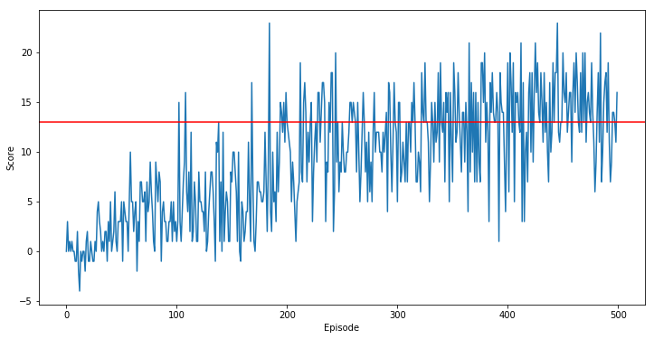

```python
from matplotlib import pyplot as plt
# Plot the scores
fig = plt.figure(figsize=(12,6))
ax = fig.add_subplot(111)
plt.plot(np.arange(len(scores)), scores)
plt.ylabel('Score')
plt.xlabel('Episode')
plt.axhline(y=SCORE_THRESHOLD, color='r', linestyle='-')
print("Banana Collector Score vs Episode (Red Line - Score Threshold)")
plt.show()
```

```python
env.close()
```

### Parameter Tuning notes

DDQN, EPS decay method 256x128x64 Cases 0: Early tuning adjusted LR .01 which was poor, LR=.001 was good  
Increased REPLAY_BUFFER 2000 to 10000 LR .0005, EPS 400, peak 800 episodes 14, then started to decline EPS Case 1: EP: 500, EPS_DECAY = 400, LR=.001 >> Episode 500: Avg: 8.0 Case 2: EP: 900, EPS_DECAY = 200, LR=.001 Episode: 300 Avg: 7.0 EPS: 0.23 Std: 2.99 TGT: -8.99 Episode: 600 Avg: 11.6 EPS: 0.06 Std: 3.42 TGT: -4.81 Episode: 900 Avg: 12.2 EPS: 0.02 Std: 3.62 TGT: -4.46 Case 3: EP: 900, EPS_DECAY = 300, LR=.001 Episode: 300 Avg: 3.8 EPS: 0.37 Std: 2.33 TGT: -11.49 Episode: 600 Avg: 9.0 EPS: 0.14 Std: 3.37 TGT: -7.38 Episode: 900 Avg: 11.8 EPS: 0.06 Std: 3.66 TGT: -4.89 **Hihger EPS_DECAY more exploration later in training Case 4: EP: 900, EPS_DECAY = 100, LR=.001 Episode: 300 Avg: 6.8 EPS: 0.06 Std: 4.12 TGT: -10.30 Episode: 600 Avg: 11.7 EPS: 0.01 Std: 3.89 TGT: -5.22 Episode: 900 Avg: 9.8 EPS: 0.01 Std: 4.92 TGT: -8.15** Lower EPS_DECAY exploration stops around 600, peaked around avg score 10-11 @ 750 eps, then declined Case 5: EP: 900, EPS_DECAY =150 Episode: 300 Avg: 5.8 EPS: 0.14 Std: 3.80 TGT: -10.98 Episode: 600 Avg: 11.3 EPS: 0.03 Std: 4.65 TGT: -6.33 Episode: 900 Avg: 10.8 EPS: 0.01 Std: 4.84 TGT: -7.01 Case 6: EP: 1200, EPS_DECAY =250 , EPS_END= .04 Episode: 300 Avg: 3.8 EPS: 0.40 Std: 2.56 TGT: -11.73 Episode: 600 Avg: 9.3 EPS: 0.18 Std: 3.41 TGT: -7.09 Episode: 900 Avg: 11.2 EPS: 0.10 Std: 3.29 TGT: -5.12  
Episode: 1200 Avg: 11.8 SAT: 0.07 Std: 3.45 TGT: -4.69

Removed DDQN, EPS decay method (compounding) Case 7: EP: 600, EPS_DECAY = .995, LR=.0005 Episode: 300 Avg: 6.5 EPS: 0.24 Std: 2.89 TGT_ZERO: -9.35 Episode: 600 Avg: 9.3 EPS: 0.07 Std: 3.68 TGT_ZERO: -7.37 Peak 570 10.5 then declining Case 8: EP: 600, EPS_DECAY = 300, LR=.001  
Episode: 300 Avg: 4.6 EPS: 0.38 Std: 2.42 TGT_ZERO: -10.80 Episode: 600 Avg: 8.9 EPS: 0.15 Std: 3.51 TGT_ZERO: -7.64 Case 9: EP: 900, EPS_DECAY = 200, LR=.001  
Episode: 300 Avg: 6.5 EPS: 0.24 Std: 2.75 TGT_ZERO: -9.29 Episode: 600 Avg: 11.5 EPS: 0.07 Std: 3.62 TGT_ZERO: -5.13 Episode: 900 Avg: 13.2 EPS: 0.03 Std: 3.66 TGT_ZERO: -3.48 Reached target threshold 13 at 850 Episodes Case 10: EP: 900, EPS_DECAY = 250, LR=.001  
Episode: 300 Avg: 5.5 EPS: 0.32 Std: 2.61 Episode: 600 Avg: 9.8 EPS: 0.11 Std: 3.83 Episode: 900 Avg: 9.9 EPS: 0.05 Std: 4.18 **Initial 300 EP of learning linear with higher slope sensitive to lower EPS_DECAY** due to higher exploration Case 10: EP: 900, EPS_DECAY = 150, LR=.001 Episode: 300 Avg: 7.6 EPS: 0.15 Std: 3.26 Episode: 600 Avg: 11.0 EPS: 0.04 Std: 3.67 Episode: 900 Avg: 11.4 EPS: 0.02 Std: 4.20 **Peak 11.2 500 Episodes Case 11: Repeate Case 9; EPS_DECAY = 200, LR=.001 Reduce BUFFER_SIZE 3000 from 10000 Episode: 300 Avg: 4.5 EPS: 0.24 Std: 2.91 Episode: 600 Avg: 9.5 EPS: 0.07 Std: 3.85 Episode: 900 Avg: 8.9 EPS: 0.03 Std: 4.47** Peak 10.2 700 Episodes Case 12: EPS_DECAY = 200, LR=.0005 Reduce BUFFER_SIZE to 60000 , BATCH_SIZE 64 to 128 Episode: 300 Avg: 6.7 EPS: 0.29 Std: 2.97 Episode: 600 Avg: 9.9 EPS: 0.13 Std: 3.38 Episode: 900 Avg: 11.1 EPS: 0.09 Std: 3.67